# Guía - Búsqueda de ayuda - CPO3523

Andrés Cruz | 2020-04

# Introducción

En esta guía vamos a revisar algunos tips y recursos para buscar ayuda efectivamente, en el contexto de proyectos de análisis de datos.

# Leer archivos de ayuda de R

Todas las funciones en R tienen un archivo de ayuda asociado. Podemos acceder a estos simplemente antecediendo el nombre de la función con un signo de interrogación:

```r
?mean

?`%>%` # con estos tildes invertidos podemos ingresar funciones que tengan caracteres especiales

?`%in%`
```

Podemos leer un archivo de ayuda de R de la siguiente forma:

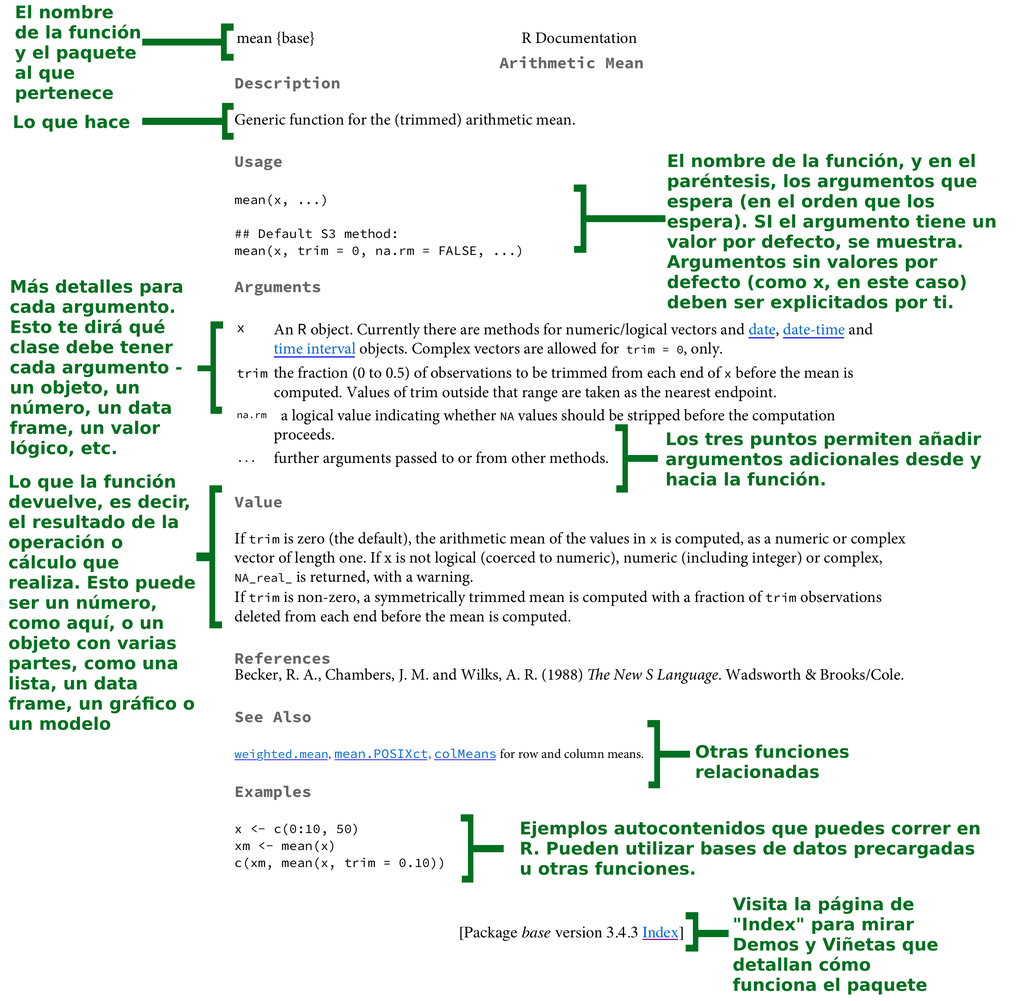

Traducido de [Healy (2018)](https://socviz.co/appendix.html).

# Encontrar funciones en línea

## [CRAN packages](https://cran.r-project.org/web/packages/available_packages_by_name.html)

CRAN es el sitio de los repositorios oficiales de R. La página web es un poco confusa, pero usualmente encontramos los paquetes que queremos buscando en Google `cran <paquete>`. Por ejemplo, este es el [sitio para el paquete `dplyr`](https://cran.r-project.org/web/packages/dplyr/).

Contiene información útil sobre el paquete. Tres campos muy importantes a mirar son (a) “URL”, que nos lleva al sitio oficial del paquete, usualmente en la página del autor/a, (B) “Vignettes”, que son pequeñas guías oficiales de cómo usarlo y (C) “Reference manual”, un manual con todos los archivos de ayuda de sus funciones.

## [rdocumentation.org](https://www.rdocumentation.org/)

En este sitio podemos buscar funciones y mirar sus archivos de ayuda en línea. Prueba a buscar alguna función conocida (por ejemplo, `mutate`, `arrange`, `select`, etc.). En la columna de la derecha aparecerán las funciones, mientras que la de la izquierda mostrará paquetes relacionados con nuestra búsqueda.

## [CRAN Task Views](https://cran.r-project.org/web/views/)

CRAN Task Views son guías muy completas sobre qué paquetes nos pueden ayudar a lidiar con tópicos específicos. Por ejemplo, veamos el [CTV de “Estadística para las Ciencias Sociales”](https://cran.r-project.org/web/views/SocialSciences.html).

# Solucionar problemas

## Problemas con paréntesis y comas

Vamos a usar una base de ejemplo de `ggplot2`, llamada `midwest`. Contiene información demográfica sobre distintos condados en Estados Unidos, parte de la zona geográfica llamada “Midwest”.

```r
midwest
```

```
## # A tibble: 437 x 28
##      PID county state  area poptotal popdensity popwhite popblack popamerindian
##    <int> <chr>  <chr> <dbl>    <int>      <dbl>    <int>    <int>         <int>
##  1   561 ADAMS  IL    0.052    66090      1271.    63917     1702            98
##  2   562 ALEXA… IL    0.014    10626       759      7054     3496            19
##  3   563 BOND   IL    0.022    14991       681.    14477      429            35
##  4   564 BOONE  IL    0.017    30806      1812.    29344      127            46
##  5   565 BROWN  IL    0.018     5836       324.     5264      547            14
##  6   566 BUREAU IL    0.05     35688       714.    35157       50            65
##  7   567 CALHO… IL    0.017     5322       313.     5298        1             8
##  8   568 CARRO… IL    0.027    16805       622.    16519      111            30
##  9   569 CASS   IL    0.024    13437       560.    13384       16             8
## 10   570 CHAMP… IL    0.058   173025      2983.   146506    16559           331
## # … with 427 more rows, and 19 more variables: popasian <int>, popother <int>,
## #   percwhite <dbl>, percblack <dbl>, percamerindan <dbl>, percasian <dbl>,
## #   percother <dbl>, popadults <int>, perchsd <dbl>, percollege <dbl>,
## #   percprof <dbl>, poppovertyknown <int>, percpovertyknown <dbl>,
## #   percbelowpoverty <dbl>, percchildbelowpovert <dbl>, percadultpoverty <dbl>,
## #   percelderlypoverty <dbl>, inmetro <int>, category <chr>
```

Generemos un gráfico con ella:

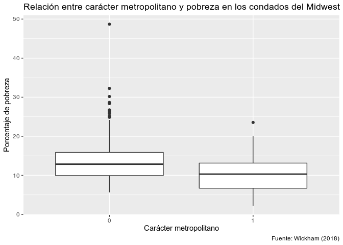

```r
ggplot(data = midwest,
       mapping = aes(x = as.factor(inmetro), y = percbelowpoverty)) +
  geom_boxplot() +
  labs(title = "Relación entre carácter metropolitano y pobreza en los condados del Midwest",
       caption = "Fuente: Wickham (2018)",
       x = "Carácter metropolitano", y = "Porcentaje de pobreza")
```

La gran mayoría de los errores que se cometen en R tienen que ver con sintaxis. Como hemos visto, R (como cualquier lenguaje de programación) espera instrucciones muy precisas de nuestra parte. Aquí algunos tips para detectar problemas de este tipo:

- **Revisar dónde abren/cierran paréntesis sospechosos**. Si ponemos el teclado al lado de uno de ellos, RStudio resaltará el paréntesis par a este:

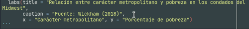

- Con respecto a las comas, debemos recordar que se utilizan para **separar argumentos de funciones**, por lo que siempre deben estar adentro de ellas. Fíjate en los argumentos de la función `labs()` en el código de arriba.
- Otro error de sintaxis es dejar cadenas de código (`%>%` o `+`) abiertas. Esto es, dejar un pipe o “+” extra al final. R seguirá esperando la continuación de la cadena!
- Un truco para ver dónde está fallando nuestro código es **“ponerle sangría” línea a línea**. Si tenemos un código desordenado, podemos ir ordenándolo línea a línea con Ctrl + I. Probablemente esto nos dé una mejor perspectiva para encontrar errores de comas, pipes, etc:

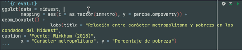

## Leer los mensajes de error de R

Veamos el siguiente error, cuando intentamos filtrar solo los condados de Illinois en la base de ejemplo:

```r
midwest %>%
  filter(state = "IL")
```

```
## Error: `state` (`state = "IL"`) must not be named, do you need `==`?
```

¿Cuál es la solución al problema? En este caso el mensaje de error es muy claro, teníamos que usar el operador lógico `==`, en vez de solo `=`.

## Buscar en internet

La mayoría de la veces, los errores que devuelve R son difíciles de entender, a diferencia del ejemplo anterior. Una buena idea es buscar el error en Google (la mayoría de los errores ya han sido preguntados en línea), acompañado de la función y/o paquete.

Para hacer estas búsquedas eficientemente, deberíamos **eliminar cualquier información del error que sea específica de nuestra base de datos** (“generalizándolo”). Por ejemplo, una buena búsqueda para el error anterior podría ser la siguiente. También eliminamos símbolos especiales (como `==`), que seguramente Google no tomará en cuenta.

> r dplyr filter must not be named, do you need

En Google podemos poner una palabra o frase entre comillas para que los resultados deban necesariamente contenerla tal como está escrita. Podríamos buscar algo como esto:

> r dplyr filter “must not be named, do you need”

Por lejos, los mejores resultados vienen de [StackOverflow](https://stackoverflow.com/), un sitio web de preguntas y respuestas de programación. En Google a menudo querrán clickear en “Más resultados de stackoverflow.com”, si es que no encuentran la solución en los primeros resultados. Podemos hacer nuestra búsqueda anterior directamente en StackOverflow a través de Google, de la siguiente forma:

> site:stackoverflow.com dplyr filter “must not be named, do you need”

# Pedir ayuda con ejemplos reproducibles (reprex)

Cuando tenemos un problema y queremos compartirlo con alguien (colegas, StackOverflow, etc.), lo ideal es que generemos un ejemplo mínimo que reproduzca nuestro problema (reprex).

- La idea es que la otra persona no tenga que lidiar con todo nuestro código, sino que solo con la parte que nos está dando problemas.
- Adicionalmente, no queremos que esa otra persona tenga que entender nuestra base de datos en particular, por lo que los *reprex* usualmente están hechos con bases de datos pequeñas creadas o con bases de datos que vienen por defecto con R o el tidyverse (`mtcars`, `midwest`, `mpg`, `diamonds`, etc.).
- Por último, queremos que esa otra persona pueda correr rápidamente nuestro código, sin tener que preocuparse de nada más aparte de nuestro problema.

Nuestro problema de antes:

```r
midwest %>%
  filter(state = "IL")
```

```
## Error: `state` (`state = "IL"`) must not be named, do you need `==`?
```

Utilizar la base “midwest” está bien, pero vamos a generar nuestro reprex con otra de ejemplo en el paquete `ggplot2`, llamada `mpg`. Esta base se ve de la siguiente forma. No importa mucho su contenido, pero sí que tenemos variables categóricas por las que querríamos filtrar, como por ejemplo “model”.

```
## # A tibble: 234 x 11
##    manufacturer model    displ  year   cyl trans   drv     cty   hwy fl    class
##    <chr>        <chr>    <dbl> <int> <int> <chr>   <chr> <int> <int> <chr> <chr>
##  1 audi         a4         1.8  1999     4 auto(l… f        18    29 p     comp…
##  2 audi         a4         1.8  1999     4 manual… f        21    29 p     comp…
##  3 audi         a4         2    2008     4 manual… f        20    31 p     comp…
##  4 audi         a4         2    2008     4 auto(a… f        21    30 p     comp…
##  5 audi         a4         2.8  1999     6 auto(l… f        16    26 p     comp…
##  6 audi         a4         2.8  1999     6 manual… f        18    26 p     comp…
##  7 audi         a4         3.1  2008     6 auto(a… f        18    27 p     comp…
##  8 audi         a4 quat…   1.8  1999     4 manual… 4        18    26 p     comp…
##  9 audi         a4 quat…   1.8  1999     4 auto(l… 4        16    25 p     comp…
## 10 audi         a4 quat…   2    2008     4 manual… 4        20    28 p     comp…
## # … with 224 more rows
```

Debemos pensar hacer la misma operación con la nueva base, y que nos dé el mismo error. Además, el reprex debe incluir la carga de paquetes:

```r
library(tidyverse) # carga filter() y mpg

mpg %>%
  filter(model = "a4")
# Error: `model` (`model = "a4"`) must not be named, do you need `==`?
```